# Többváltozós OLS Regresszió alapjai

Kovács László

2024. 05. 23.

## 1. Magyar járások COVID-19 halálozási arányai

A COVID_JarasData.xlsx fájl egy olyan adattábla, ami 102 magyar járásról (azokról, ahol a kórházak 2019-ben átlagos vagy átlag alatti leterheltségűek voltak a [NEAK adatai](http://www.neak.gov.hu/data/cms1026624/Korhazi_agyszamkimutatas_2019.pdf) alapján) 5 változó (oszlop) adatát tárolja:

- **Jaras**: A járás neve
- **COVIDHalal**: COVID-19 halálozási arány: elhunytak / fertőzöttek hányadosa (%) 2021.03.04-én. Forrás: [atlatszo.hu](https://bit.ly/COVID-adatok)
- **Apolok**: Háziorvosi szakápolók/ápolók száma 10000 főre (2019) Forrás: KSH
- **Munkanelkuliseg**: Nyilvántartott álláskeresők száma 10000 főre (2019) Forrás: KSH
- **Nok65Felett**: Lakónépességből a 65 éves és idősebb nők aránya (%) (2019) Forrás: KSH

Olvassuk be a fájlt egy pandas `data frame`-be a pandas sima `read_excel` függvényével:

```python
# Elemzéshez és ábrázoláshoz szükséges csomagok betöltése
import numpy as np
import pandas as pd
import matplotlib.pyplot as plt
import scipy.stats as stats

# 102 járás adatainak beolvasása
covid = pd.read_excel("COVID_JarasData.xlsx")
covid.info()
```

```
## <class 'pandas.core.frame.DataFrame'>
## RangeIndex: 102 entries, 0 to 101
## Data columns (total 5 columns):
##  #   Column           Non-Null Count  Dtype
## ---  ------           --------------  -----
##  0   Jaras            102 non-null    object
##  1   COVIDHalal       102 non-null    float64
##  2   Apolok           102 non-null    float64
##  3   Munkanelkuliseg  102 non-null    float64
##  4   Nok65Felett      102 non-null    float64
## dtypes: float64(4), object(1)
## memory usage: 4.1+ KB
```

Láthatjuk, hogy megvan minden oszlop, amit a leírásban megadtunk. Megvan mind a négy numerikus (azaz `float`, mert törtszámokról van szó) típusú oszlopunk, és a **Jaras** oszlop maradhat `object`, azaz “szöveges” adattípusban, hiszen ez a járások azonosítója, minden név csak egyszer fordul elő a táblában, statisztikai elemzéseknek értelemszerűen nem vetjük alá ezt a változót. :)

Adja magát a dolog, hogy megpróbáljuk **kétváltozós regressziókkal** elemezni azt, hogy miképpen függ a vizsgált járásokban a COVID halálozási arány a másik három változótól (ápolók, munkanélküliek száma 10 ezer főre, 65 éven felüli nők aránya).

Első logikus gondolat azt diktálja, hogy hát minél több ápolója van népességarányosan egy járásnak, annál kevesebb lesz a COVID halálozási arány, hiszen a több ápoló jobba ellátást tud biztosítani. Teszteljük is le az elméletünket: csináljunk egy regressziót, ahol eredményváltozó ($Y$) a **COVIDHalal**, magyarázóváltozó ($X$) pedig az **Apolok**!

Első körben nézzük meg egy $R^2$ segítségével milyen szoros a két változónk köztü kapcsolat:

```python
(stats.pearsonr(covid.Apolok, covid.COVIDHalal)[0]**2)*100
```

```
## 17.627405081896164
```

Alapvetően az $R^2$ szép, korrekt dolgokat mutat. Az ápolók száma kb. 18 %-ban megmagyarázza a COVID halálozás alakulását a vizsgált járások körében ($R^2=17.6\%$), ami egy közepes magyarázóerőnek minősíthető, hiszen $10\% < R^2 < 50\%$.

Nézzük meg, hogy néz ki a regressziós egyenes egyenlete! Használjuk nyugodtan a 11. heti tananyag 6. fejezetében megismert `polyfit` függvényét a `numpy` csomagnak:

```python
Beta1, Beta0 = np.polyfit(covid.Apolok, covid.COVIDHalal, deg = 1)
print([Beta1, Beta0])
```

```
## [0.36293219444301944, 2.0204369252121204]
```

A 102 járás adatából illesztett regressziós modell szerint tehát:
$$Becsult COVIDHalal= 0.36 \times Apolok +
2.02$$

**Ajjajjaj!** A modell **meredeksége pozitív**!! Konkrétan, ha a járásban az ápolók száma 10 ezer főre nő 1-gyel, akkor várhatóan a COVID halálozási arány is **növekedni** fog 0.36 százalékponttal! Ez alapján úgy tűnik, hogy mintha megérné kevesebb ápolót tartani, mert akkor fog csökkenni a COVID halálozás a járásban. Ezt az eredményt így nagyon nem eszi meg a gyomrunk!

A fura eredmény háttérben egy úgynevezett **confunding** nevű jelenség áll!

Lessük csak meg a minden **covid** `data frame`-ben lévő numerikus változó korrelációmátrixát! Ez egy oylan táblázat, amiben az egyes numerikus változók közti korrelációkat mutatja meg nekünk a gépállat. Simán egy `data frame` numerikus változóiból a `data frame`-n elsütött `cor` metódussal hívható elő.

```python
covid.corr()
```

```
##                  COVIDHalal    Apolok  Munkanelkuliseg  Nok65Felett
## COVIDHalal         1.000000  0.419850         0.495429     0.411443
## Apolok             0.419850  1.000000         0.540570     0.517462
## Munkanelkuliseg    0.495429  0.540570         1.000000     0.228315
## Nok65Felett        0.411443  0.517462         0.228315     1.000000
```

A korrelációkból látszik, hogy a **COVIDHalal** változóval a másik három változó egyirányú, és közepes erősségű kapcsolatban állnak (mindegyik korreláció a COVIDHalal oszlopában, ami nem az önmagával vett korrelációt jelenti az +0.4 körüli érték). Ez a **Munkanelkuliseg** és **Nok65Felett** változók esetén logikus is, hiszen a COVID elsősorban a 65 év felettiek körében halálos, illetve azok körében ahol eleve több alapbetegség jelen volt. Ahol magas a munkanélküliség, ott pedig eleve rosszabb az egészségi állapot: alkoholizmus, szív- és érrendszeri problémák gyakoriak a magas munkanélküliségű járásokban (lásd pl. ezt a tanulmányt).  
NODE, az **Apolok** egyirányú módon és közepes erősségben összefügg a **Munkanelkuliseg** és **Nok65Felett** változókkal is! Tehát, valószínűleg a magas 10 ezer főre jutó ápolószámmal bíró járásokban *csak azért magas a COVID halálozás*, mert ezekben a járásokban magas a munkanélküliség és az idős népesség aránya is! Tehát a népesség egészségi állapota ezen járásokban **eleve rosszabb**!  
Na, ez a jelenség a **confunding**: amikor egy változó csak azért korrelál egy másikkal, mert **valójában egy vagy több másik változó hatását közvetíti a saját hatásán túl**.

Szóval, a feladat adott: fejtsük meg, hogy ha leválasztjuk az **Apolok** változóról a **Munkanelkuliseg** és **Nok65Felett** változók hatását (azaz kiszűrjük/megtisztítjuk a *confunding* hatást), akkor hogyan hat az **Apolok** változó **önállóan** a **COVIDHalal**-ra!
Erre a feladatra eszözünk a **többváltozós lineáris regresszió**! Ami egyszerűen a sima $\hat{Y}=\beta_1 X + \beta_0$ kétváltozós regresszió kiterjesztése úgy, hogy az egyenletbe tetszőleges, konkrétan $k$ db magyarázóváltozót rakunk be, és mindenkinek meglesz a maga $\beta$-ja:
$$\hat{Y}=\beta_1 X_1 + \beta_2 X_2 + ... + \beta_k
X_k + \beta_0$$

Az előbbi egyenlet alapján a **többváltozós lineáris regresszió**t úgy is értelmezhetjük, mint egy olyan statisztikai modellt, ami a COVID halálozási arányokat akarja előrejelezni **egyszerre az ápolószám, munkanélküliség és 65 év feletti női népesség aránya** segítségével!

## 2. A Többváltozós Lineáris Regresszió OLS elvű előállítása

A nagy szerencsénk, hogy a többváltozós regresszióban is lényegében változtatás nélkül működik a $\beta_j$-k OLS elvű meghatározási módja.  
Azaz, úgy választjuk meg a $\beta_j$-ket, hogy az COVID halálozási arányokra ($Y$) adott becsléseink hibája minimális legyen. A becslési hibát az ún. SSE mutatóval mérjük továbbra is: $Sum of Squared Errors (SSE) = \sum_{i=1}^n(y_i-\hat{y_i})^2$.

Az továbbra is igaz lesz, hogy négyzetesen mért hiba esetében a gép itt **sem vaktában keresi** a $\beta$-kat! Az OLS feladat megoldása (tehát a legkisebb $SSE$-t adó $\beta$-k) kifejezhetők egy fix képlettel itt is!

Az $SSE=\sum_{i=1}^n(y_i-\hat{y_i})^2=\sum_{i}(y_i-\sum_{j}\beta_jx_j)^2$ képlet kifejezhető mátrixosan is, ha bevezetjük az $X$ mátrikot, aminek az első oszlopa csupa 1-et tartalmaz (a tengelymetszet miatt) és a többi oszlopaiba az $X_j$-ket rakjuk, akkor az $SSE$-t így is fel tudjuk írni: $SSE=||y-X\beta||^2$. Ha ezt a mátrixosan kifejezett függvényt deriváljuk a $\beta$-k szerint, és a deriváltakat egyenlővé tesszük 0-val, akkor kifejezhető az a fix formula, amivel az OLS elven számított $\beta$-k vektora megadható: $\beta=(X^TX)^{-1}X^Ty$.

Azt, hogy konkrétan hogyan jön ki ez a csodaszép mátrixos formula, nekünk annyira nem fontos. A gyakorlati szempontból azt kell látni, hogy minimalizálási feladathoz többváltozós regresszió esetén sem kell a 3. gyakorlaton látott `optim` függvény, mert a megoldása egy fix mátrixos képlet. **Emiatt használják az OLS regressziót mai napig előszeretettel: fix képlettel megadhatók a $\beta$ együtthatók többváltozós esetben is!**

Az a nagy szerencse, hogy a mi három magyarázóváltozót használó modellünk együtthatóit ilyen OLS elven meg lehet becsültetni Pythonban a `statsmodels` csomag `OLS` nevű függvényével. Ehhez először importáljuk a csomag függvényeit egy `sm` c. névtérbe.

```python
import statsmodels.api as sm
```

A függvény használatához először el kell különíteni egy külön objektumba az eredményváltozó oszlopát a vizsgált `data frame`-ből. Hívjuk most ezt az objetktumot `Y`-nak.

```python
Y = covid.COVIDHalal
```

Majd ezek után egy külön `data frame`-be összegyűjtöm csak a magyarázóváltozókat, hívjuk ezt az új `data frame`-t most szimplán `X`-nek. Utána a `statsmodels` csomag `add_constant` függvényével hozzáadunk egy csupa $1$-ből álló oszlopot, ahogy a regresszió korábban látott mátrixos felírásában is vettük az $X$ mátrixot.

```python
X = covid.loc[:,['Apolok','Munkanelkuliseg','Nok65Felett']]
X = sm.add_constant(X)
X
```

```
##      const     Apolok  Munkanelkuliseg  Nok65Felett
## 0      1.0   7.354416       369.057966    14.735575
## 1      1.0  10.385919       227.396961    14.873729
## 2      1.0   6.256924       227.403274    13.129282
## 3      1.0   4.421334        65.454965    11.351294
## 4      1.0   6.876948       676.691729    12.350999
## ..     ...        ...              ...          ...
## 97     1.0   7.377035       625.503954    14.313164
## 98     1.0   7.567731       586.751425    14.237425
## 99     1.0   5.884826       287.876058    13.452231
## 100    1.0   8.136283       520.722095    16.730231
## 101    1.0   8.535544       338.983051    15.522497
##
## [102 rows x 4 columns]
```

És végül akkor az `sm` névtér `OLS` függvényébe berakjuk ezeket az újonnan létrehozott `Y` és `X` Python objektumokat (kötelezően ebben a sorrendben), és végül meghívunk az egészen egy `fit()` metódust. Az eredményt pedig egy külön Python objektumba kell elmenteni.

```python
sokvalt_modell = sm.OLS(Y,X).fit()
```

A többváltozós regressziós modell legfontosabb statisztikai mutatóit egy nap összefoglaló táblázatban az az újonnan létrehozott `sokvalt_modell` objektum `summary()` metódusával lehet lekérdezni.

```python
print(sokvalt_modell.summary())
```

```
##                             OLS Regression Results
## ==============================================================================
## Dep. Variable:             COVIDHalal   R-squared:                       0.341
## Model:                            OLS   Adj. R-squared:                  0.321
## Method:                 Least Squares   F-statistic:                     16.89
## Date:                Cs, 23 máj. 2024   Prob (F-statistic):           6.42e-09
## Time:                        22:12:48   Log-Likelihood:                -152.39
## No. Observations:                 102   AIC:                             312.8
## Df Residuals:                      98   BIC:                             323.3
## Df Model:                           3
## Covariance Type:            nonrobust
## ===================================================================================
##                       coef    std err          t      P>|t|      [0.025      0.975]
## -----------------------------------------------------------------------------------
## const              -0.1542      0.937     -0.165      0.870      -2.015       1.706
## Apolok              0.0445      0.096      0.463      0.644      -0.146       0.235
## Munkanelkuliseg     0.0028      0.001      4.099      0.000       0.001       0.004
## Nok65Felett         0.2656      0.087      3.053      0.003       0.093       0.438
## ==============================================================================
## Omnibus:                       25.226   Durbin-Watson:                   1.957
## Prob(Omnibus):                  0.000   Jarque-Bera (JB):               36.179
## Skew:                           1.173   Prob(JB):                     1.39e-08
## Kurtosis:                       4.735   Cond. No.                     3.10e+03
## ==============================================================================
##
## Notes:
## [1] Standard Errors assume that the covariance matrix of the errors is correctly specified.
## [2] The condition number is large, 3.1e+03. This might indicate that there are
## strong multicollinearity or other numerical problems.
```

Nézzük meg mit látunk a `summary` eredményeként:

- Mivel az OLS elvű becslése, tehát a teljes modellhiba $SSE$ elvű mérése megmaradt, így $R^2$-et továbbra is tudunk számolni $R^2=1-\frac{SSE}{SST}$ módon. Az értelmezése pedig annyiban módosul, hogy azt adja meg **hány százalékban magyarázza az eredményváltozót a magyarázóváltozók összessége**. Arra figyeljünk, az előbbi értelmezés miatt, hogy korreláció négyzeteként már **NEM** számolható a mutató, hiszen korreláció *egyszerre csak két változó kapcsolatát tudja leírni*, kettőnél több több változóét már nem. Ez alapján jelen szituációban azt mondhatjuk el, hogy az ápolók száma, 65 feletti női népesség aránya és munkanélküliség **együtt** $34\%$-ban magyarázzák a COVID halálozási arányok ingadozását a járások között. Ez érezhető magyarázóerő növekedés a kétváltozós modellhez képest, ahol csak az **Apolok** hatását vizsgáltuk.
- A Globális F-próba p-értéke most is jó alacsony, mivel `Prob (F-statistic)` = $6.42 \times 10^{-9}$. Tehát, nem meglepő módon azt mondhatjuk, hogy minden szokásos $\alpha$-n elutasíthatjuk, azt a $H_0$-t, hogy az $R^2$ összeomlik 0-ba a mintán kívüli világban. Amit itt érdemes megfigyelni az a p-érték számoláshoz használt F-eloszlás szabadságfokai. Most nekünk ugye $k=3$ magyarázóváltozónk van, az azt jelenti, hogy a regresszióban $p=4$ paramétert, azaz $\beta_j$-t kellett megbecsülnie az OLS-nek a tengelymetszet miatt. Ez alapján az F-eloszlás első szabadságfoka $p-1=3=k$, míg a második szabadságfok $n-p=102-4=98=n-k-1$.
- Ezen kívül az F-próba hipotéziseit úgy is fel lehet írni, mint: $H_0: \beta_j=0 \forall j$, azaz minden $\beta$ a mintán kívüli világban 0-nak vehető, semminek nincs magyarázóereje $Y$-ra. És $H_1: \exists j:\beta_j \neq 0$, tehát van legalább egy darab $\beta$, ami nem nulla a mintán kívüli világban, és a hozzá tartozó $X_j$-nek van hatása $Y$-ra a mintán kívüli világban is.

A `Coefficients` táblából ismét felírható a megbecsült modell egyenlete:
$$BecsultCOVIDHalal=0.04
\times Apolok + 0.003 \times Munkanelkuliseg + 0.27 \times Nok65Felett -
0.15$$

Az egyenlet olyan szempontból furának tűnik, hogy az **Apolok** együtthatója még mindig pozitív, bár tény, hogy már csak $0.04$ az értéke a kétváltozós modell $0.36$-os meredeksége helyett.  
Ahhoz, hogy pontosan megértsük mit is takar ez a $0.04$ és megadjuk hogyan lehet megmérni egy magyarázóváltozó ($X_j$) fontosságát a regressziós modellünk előrejelzéseiben, egy kicsit alaposabban meg kell érteni mit is takarnak ezek a $\beta_j$ értékek a többváltozós regresszióban.

## 3. A magyarázóváltozók marginális hatása

Ahogyan a 2. fejezetben írtam, a az OLS regressziót azért használják a mai napig előszeretettel, mert fix képlettel megadhatók a $\beta_j$ együtthatók. De ez csak az egyik oka a modell népszerűségének. A másik az, hogy a $\beta_j$ együtthatók megfeleltethetők a hozzájuk tartozó $X_j$ magyarázóváltozók **marginális hatásának**.

Az $X_j$ magyarázóváltozó marginális hatása az a hatás, amit ő **egyedül és közvetlenül** fejt ki az $Y$ eredményváltozó alakulására. OLS regresszióban ez a marginális hatás $X_j$ magyarázóváltozó esetében épp a $\beta_j$ együttható lesz.

Most ez alapján egy $\beta_j$ általános értelmezése a következő: **Ha az adott bétához tartozó magyarázóváltozó értéke egy egységgel nő a többi magyarázóváltozó értékének változatlansága mellett, akkor az eredményváltozó értéke várhatóan bétányit változik.**

Ennek az értelmezésnek **3 kötelező eposzi kelléke** van:

1. Minden változás az eredményváltozó és az éppen vizsgált magyarázóváltozó **saját mértékegységében** értendő
2. Az éppen nem vizsgált magyarázóváltozók értékéről feltesszük, hogy nem változnak. Ezzel az éppen vizsgált $X_j$ közvetlen hatását mérjük meg $Y$-ra. Ez a **ceteris paribus elv**.
3. A $\beta_j$ az $Y$-ban okozott **várható** változást mutatja csak! Ez a változás akkor lenne egész biztosan épp $\beta_j$-nyi, ha $R^2=100\%$ lenne.

Ha ez az értelemzés így általánosságban igaz, akkor az **Apolok** $+0.04$-es $\beta$-ja a többváltozós regressziónkban már megtisztult a munkanélküliség és a 65 év feletti népesség **confunding** hatásától, hiszen a $0.04$ egy ezek megváltozása *nélküli* +1 egység **Apolok** növekedés esetén mutatja be a COVID halálozás várható változását.

Ezek alapján nézzük meg a jelenlegi modellünkben vett $\beta_j$-k értelmezése! Ha csak a modell $\beta_j$-it akarom lekérdezni és semmi egyebet, akkor azt a modellt tartalmazó Python objektum `params` tulajdonságának lekérdezésével tudom megtenni.

```python
sokvalt_modell.params
```

```
## const             -0.154215
## Apolok             0.044522
## Munkanelkuliseg    0.002819
## Nok65Felett        0.265567
## dtype: float64
```

- $\beta_1=0.04$: Ha egy járásban a 10 ezer főre jutó ápolók száma nő 1 fővel változatlan munkanélküliség és 65 év feletti női népesség mellett, akkor a járás COVID halálozási aránya várhatóan 0.04 százalékponttal emelkedik. Ez még mindig nem tűnik szimpatikusnak, de majd mindjárt a végére járunk.
- $\beta_2=0.003$: Ha egy járásban az álláskeresők száma 10 ezer fővel (azaz a 10 ezer főre jutó álláskeresők száma 1 fővel) nő változatlan ápolószám és 65 év feletti női népesség mellett, akkor a járás COVID halálozási aránya várhatóan 0.003 százalékponttal emelkedik. Egy fokkal magyarosabban: Ha két azonos ápolószámú és azonos 65 év feletti női népességgel bíró járás közül az egyiknek 10 ezer fővel több munkanélkülije van, akkor ott várhatóan 0.003 százalékponttal nagyobb esélye van egy COVID fertőzöttnek meghalni.
- $\beta_3=0.27$: Ha egy járásban a 65 év feletti női népesség aránya 1 százalékponttal nő változatlan ápolószám és munkanélküliség mellett, akkor a járás COVID halálozási aránya várhatóan 0.27 százalékponttal emelkedik. Egy fokkal magyarosabban: Ha két azonos ápolószámú és munkanélüliségű járás közül az egyik népességében 1 százalékponttal több lesz a 65 év feletti nők aránya, akkor ott várhatóan 0.27 százalékponttal nagyobb esélye van egy COVID fertőzöttnek meghalni.

Persze van még **egy $\beta_0$ tengelymetszetünk, ami hivatalosan azt mutatja meg, hogy mennyi lenne az $\hat{Y}$, ha a modellben minden magyarázóváltozó ($X_j$) 0 értéket venne fel**.  
Ez esetünkben azt jelenti, hogy egy 0 ápolójú, 65 év feletti nők nélküli és teljes foglalkoztatottságú járás COVID halálozási aránya a modellünk alapján $-0.15\%$. Nyilván ezzel az értelmezéssel most nem kell foglalkozni, mivel a $\forall X_j=0$ hely jelen tématerületen nem létezik. Ha valaki talál egy ilyen *csupa 0* járást, akkor viszont meneküljön onnan, mert jönnek a zombik :) (negatív halálozási arány :))

### 3.2. Útelemzés

Az a tény, hogy többváltozós regresszióban a $\beta_j$ együtthatók megfeleltethetők a hozzájuk tartozó $X_j$ magyarázóváltozók **marginális hatásának**, elvezet minket az egyes $X_j$ magyarázóváltozók közvetlen és közvetett hatásának fogalmához. Egy tetszőleges $X_j$ magyarázóváltozó közvetlen és közvetett hatásait konkrétan, számszerűen is ki lehet fejezni a regressziós $\beta$-k segítségével.

Vegyük az eddig is vizsgált **Apolok** változó közvetlen és közvetett hatásait az alábbi ábrán szemléltetve az 1. fejezet korrelációmátrixából alapján kiindulva. Ugye a korrelációk alapján az volt az elképzelésünk, hogy **az ápolók száma csak azért lehet magas pozitív korrelációban a COVID halálozással, mert a nagyobb munkanélküliség jellemzően nagyobb ápolószámmal jár együtt, és a magas munkanélküliség megnövelte a COVID halálozást, az ápolószámnak meg lehet, hogy önállóan semmi hatása nincs**. Lássuk, hogy a **regressziós együtthatók igazolják-e ezt az elképzelést**!

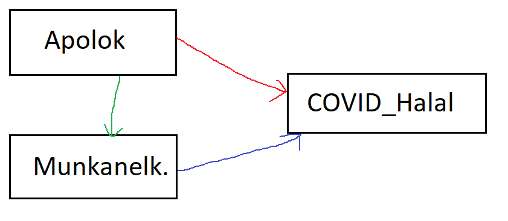

Itt a *piros* nyíl jelöli az **Apolok** közvetlen hatását a **COVIDHalal**-ra, míg a *kék* nyíl a **Munkanelkuliseg** közvetlen hatását a **COVIDHalal**-ra. A *zöld* nyíl pedig az **Apolok** hatása a **Munkanelkuliseg**-re.

A piros és kék nyilakon lévő közvetlen hatások nagyságát megadja a $BecsultCOVIDHalal=\beta_1 \times Apolok + \beta_2 \times Munkanelkuliseg + \beta_0$ regresszió $\beta_1$ és $\beta_2$ együtthatója. Szóval nyejük is ki ezeket a $\beta$-kat külön R objektumokba:

```python
# először legyártjuk a két magyarázóváltozós regressziót
X_ketvalt = covid.loc[:,['Apolok', 'Munkanelkuliseg']]
X_ketvalt = sm.add_constant(X_ketvalt)
ketmagyvalt_modell = sm.OLS(Y, X_ketvalt).fit()

# megnézzük az együtthatókat tartalmazó tömböt
ketmagyvalt_modell.params
```

```
## const              2.326507
## Apolok             0.185685
## Munkanelkuliseg    0.002669
## dtype: float64
```

```python
# a tömb 2. és 3. elemét a neveik alapján elmentjük: figyeljünk, hogy a 0. indexű elem a Béta_0!
Beta_Apolok_COVID = ketmagyvalt_modell.params['Apolok']
Beta_Munkanelk_COVID = ketmagyvalt_modell.params['Munkanelkuliseg']
```

A zöld nyílon található hatás nagyságát pedig egyszerűen a $BecsultMunkanelkuliseg = \beta_1 \times Apolok + \beta_0$ kétváltozós regresszió $\beta_1$ együtthatója adja meg. Ezt is mentsük le külön Python objektumokba:

```python
# legyártjuk a két magyarázóváltozós regresszió együtthatóit, és a meredekség lesz a "zöld nyíl" értéke
Beta1_Apolok_Munkanelk, Beta0_Apolok_Munkanelk = np.polyfit(covid.Apolok, covid.Munkanelkuliseg, deg=1)
```

Ezzel pedig megadható az $Apolok \rightarrow COVIDHalal$ kapcsolat *közvetlen és közvetett* hatásai:

```python
# közvetlen hatása az ápolók számának a COVID halálozásra (piros nyíl)
Kozvetlen_Apolok_COVID = Beta_Apolok_COVID
Kozvetlen_Apolok_COVID
```

```
## 0.18568467374999498
```

```python
# közvetett hatása az ápolók számának a COVID halálozásra (zöld*kék nyíl)
Kozvetett_Apolok_COVID = Beta1_Apolok_Munkanelk * Beta_Munkanelk_COVID
Kozvetett_Apolok_COVID
```

```
## 0.1772475206930266
```

Hiszen a **közvetett** hatás csupán annyi, hogy annyiszor kell venni a $Munkanelkuliseg \rightarrow COVIDHalal$ közvetlen hatást (kék nyíl), ahányszor megváltozik a **Munkanelkuliseg** egy egység **Apolok** növekedésre (zöld nyíl). Ezt pedig éppen a `Beta_Apolok_Munkanelk` adja meg!

Ezzel pedig megadható a $Apolok \rightarrow COVIDHalal$ kapcsolat *teljes* hatása:

```python
# teljes hatás = közvetlen + közvetett hatás
Teljes_Apolok_COVID = Kozvetlen_Apolok_COVID + Kozvetett_Apolok_COVID
Teljes_Apolok_COVID
```

```
## 0.3629321944430216
```

És jé, ez az érték pont ugyan az, mint *az eredeti $BecsultCOVIDHalal = \beta_1 \times Apolok + \beta_0$ kétváltozós regresszió $\beta_1$ meredeksége! :)

```python
Beta1 # Ezt ugye még az 1. fejezetben hoztuk létre!
```

```
## 0.36293219444301944
```

Tehát, tényleg az eredeti kétváltozós regresszióban lévő **confunding** hatást tudtuk letisztítani a többváltozós regresszióval az **Apolok** változóra nézve!

Nyilván hasonló módon lehetne megmérni, hogy mennyi az $Apolok \rightarrow COVIDHalal$ kapcsolatban a **Nok65Felett** változó *közvetett hatása* miatt fellépő **confunding** hatása a $BecsultCOVIDHalal = \beta_1 \times Apolok + \beta_0$ kétváltozós regresszió $\beta_1$ meredekségében.

### 3.3. Parciális t-próba

A magyarázóváltozók fontosságát hipotézisvizsgálattal is meg tudjuk mérni. Egy tetszőleges $X_j$ magyarázóváltozó fontosságát az alábbi null- alteranatív hipotézis páros tesztelésével tudjuk megállapítani:

- $H_0: \beta_j=0$ ~ $X_j$ hatása $Y$-ra a mintán kívül **nem szignifikáns**
- $H_1: \beta_j\neq0$ ~ $X_j$ hatása $Y$-ra a mintán kívül **szignifikáns**

Tehát ebben a hipotézisvizsgálatban, amit *parciális t-próbának* fogunk hívni, **azt mondja a $H_0$, hogy $X_j$ hatása az eredményváltozóra csak egy mintavételi hiba, ha megfigyelnék új egyedeket (azaz új járásokat), akkor a mintában mért hatás megszűnne, azaz $\beta_j$ kinullázódna**.

Ehhez a hipotézisvizsgálathoz kell nekünk a Globális F-próbánál látottak alapján egy próbafüggvény és p-érték is.

A próbafüggvényhez ad nekünk a Python egy **standard mintavételi hibát, angolul standard errort**. Ez van a `summary` metódus által kigenerált együtthatótábla 2. oszlopában:

```python
print(sokvalt_modell.summary())
```

```
##                             OLS Regression Results
## ==============================================================================
## Dep. Variable:             COVIDHalal   R-squared:                       0.341
## Model:                            OLS   Adj. R-squared:                  0.321
## Method:                 Least Squares   F-statistic:                     16.89
## Date:                Cs, 23 máj. 2024   Prob (F-statistic):           6.42e-09
## Time:                        22:12:52   Log-Likelihood:                -152.39
## No. Observations:                 102   AIC:                             312.8
## Df Residuals:                      98   BIC:                             323.3
## Df Model:                           3
## Covariance Type:            nonrobust
## ===================================================================================
##                       coef    std err          t      P>|t|      [0.025      0.975]
## -----------------------------------------------------------------------------------
## const              -0.1542      0.937     -0.165      0.870      -2.015       1.706
## Apolok              0.0445      0.096      0.463      0.644      -0.146       0.235
## Munkanelkuliseg     0.0028      0.001      4.099      0.000       0.001       0.004
## Nok65Felett         0.2656      0.087      3.053      0.003       0.093       0.438
## ==============================================================================
## Omnibus:                       25.226   Durbin-Watson:                   1.957
## Prob(Omnibus):                  0.000   Jarque-Bera (JB):               36.179
## Skew:                           1.173   Prob(JB):                     1.39e-08
## Kurtosis:                       4.735   Cond. No.                     3.10e+03
## ==============================================================================
##
## Notes:
## [1] Standard Errors assume that the covariance matrix of the errors is correctly specified.
## [2] The condition number is large, 3.1e+03. This might indicate that there are
## strong multicollinearity or other numerical problems.
```

Itt pl. a $0.096$ érték azt jelenti, hogy az **Apolok** bétája a mintában 0.04, de ez az érték a megfigyelt mintán kívül, új járásokra is futtatva a regressziót, ingadozhat a 0.04 körül, *várhatóan* +- 0.096-tal. A $\beta_j$ és standard hibájának ($SH_j$) hányadosa lesz az ún. *t-érték = t value*, ami a parciális t-próba c. hipotézisvizsgálat próbafüggvénye. Az **Apolok** változó esetében ez 0.463

A próbafüggvény eloszlása sok-sok mintavételt vizsgálva igaz $H_0$ esetén t-eloszlású, aminek a pontos alakját egy darab szabadságfok szabályozza, ami most $df=n-p=n-k-1$, ami a Globális F-próbában a 2. szabadságfok volt.

Itt $H_0$ szempontjából a legjobb eset, ha $\beta_j=0$ a mintában is, hiszen $t=\frac{\beta_j}{SH_j}$. A t-eloszlás alakja miatt viszont így a p-értéket úgy kell számolni a 0 ponttól lefelé és felfelé vett eltérések esetén is csökkenjen a $H_0$ elutasításának hibavalószínűsége:

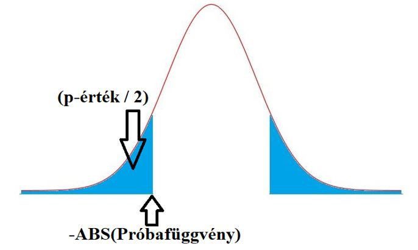

Így R-ben a p-érték: `2*stats.t.cdf(-abs(0.0445/0.096), df = 102-4)`$= 0.644$. Ezt adja meg a `summary` metódus eredménytáblája a `P>|t|` oszlopban.

Végkonklúzióként, tehát azt vonhatjuk le a modellünk alapján, hogy az **ápolók számának COVID halálozásra gyakorolt pozitív hatása a kétváltozós regresszióban látszólagos volt csupán, és a munkanélküliség valamint 65 feletti női népesség arányának COVID halálozást növelő hatásait közvetítette csak, és semmi önálló szignifikáns marginális hatása nem volt**!

Ezek a változónkénti t-próba p-értékek azért nagyon jók, mert ezek alapján nagyon könnyű egy fontossági sorrendet felállítani a regressziónk magyarázóváltozói között. Az eddigiek alapján röviden-tömören: minél kisebb a parciális t-próba p-értéke, annál fontosabb az adott magyraázóváltozó az eredményváltozó előrejelezésében (annál kevésbé vehető marginális hatása $0$-nak a sokaságban)